# Biomedical engineering research in Chilean universities - A bibliometric analysis

[figure not shown]

## 1. Abstract

Biomedical engineering (BME) combines engineering, biology, and medicine to develop innovative healthcare solutions. There is an increasing demand for BME professionals following technological and scientific advances. In Chile, only three universities offer undergraduate BME programs: Universidad de Valparaíso, Universidad de Concepción, and Universidad de Santiago de Chile. Each institution has defined its curriculum, professional profile, and research focus based on its perspective of the country’s needs. However, the scope of their research contribution has not been studied. In this work, we perform a comprehensive bibliometric analysis using data from the SCOPUS database to evaluate publications by researchers affiliated with Chilean undergraduate BME programs from 2000 to 2022. The objective is to identify the research areas of BME in Chile, understand the similarities and differences between universities, analyse their research areas, explore collaboration relationships, and characterise the discipline’s evolution. The main contributions of this work are (1) a quantitative and qualitative analysis of BME research in Chile, (2) the identification of BME research areas and their development over time, (3) the creation of a dashboard-style web tool, and (4) proposing a robust methodology for bibliometric analysis applicable to BME literature in Chile and similar contexts. This work represents the first collaboration involving authors from all universities with undergraduate Chilean BME programs.

## 2. Code

This document was created to present the analysis related to the paper and to demonstrate the methodology behind the creation of the figures.

### 2.1 BME undergraduate profiles

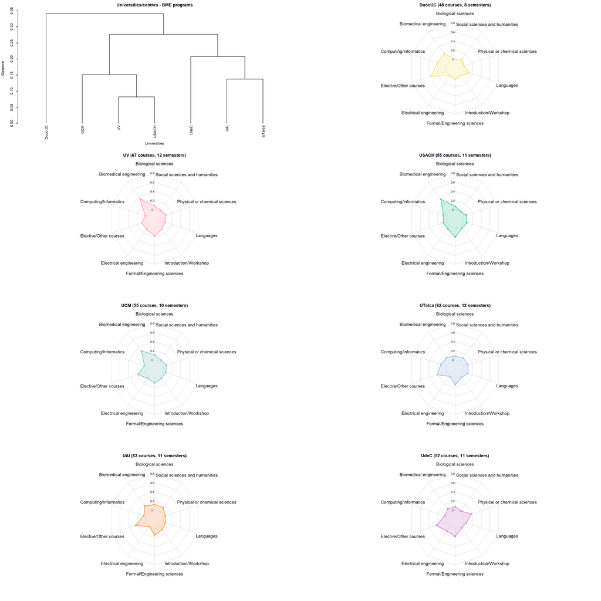

```r
# Load necessary libraries
library("fmsb")  # Provides statistical functions for exploratory data analysis.
library("dplyr")  # Used for data manipulation and transformation.
library("gridExtra")  # Allows arranging multiple grid-based figures on one page.

# Read data from CSV file
data_courses = read.csv("Data/BD_cursos.csv", sep=";", header = TRUE)

# Dictionary of classes of courses
course_classes = sort(unique(data_courses$Clasificación))

universities = c("UV", "UCM","UAI","DuocUC","USACH", "UTalca", "UdeC")
frequency_course = NULL

titles_course = c("UV (67 courses, 12 semesters)", "UCM (55 courses, 10 semesters)","UAI (63 courses, 11 semesters)",
                  "DuocUC (48 courses, 8 semesters)","USACH (55 courses, 11 semesters)", "UTalca (62 courses, 12 semesters)",
                  "UdeC (52 courses, 11 semesters)")

colours = c("lightpink1","paleturquoise3","sandybrown","khaki","mediumaquamarine","lightsteelblue","plum3")

# Loop through universities
for (a in universities) {
  # Filter by university
  idx = which(data_courses$Universidad == a)
  data_subset = data_courses$Clasificación[idx]

  # Calculate the frequency of elements in vector_1 in vector_2
  freq_tmp = table(factor(data_subset, levels = unique(course_classes)))
  frequency_course = rbind(frequency_course, round(freq_tmp/sum(freq_tmp), 3))
}
frequency_course = as.data.frame(frequency_course)
rownames(frequency_course) = universities

# Set up plot parameters
par(mar=c(1, 2, 2, 1))  # Decrease default margin
idx = nrow(frequency_course)
layout(matrix(1:8, ncol=2))  # Arrange plots on the device (suppress messages)

# Compute distance matrix and dendrogram
distancia_courses = dist(frequency_course)
hc = hclust(distancia_courses, method = "average")

# Adjust bottom margin for dendrogram
par(mar = c(5, 4, 2, 2) + 0.1)

# Plot dendrogram
plot(as.dendrogram(hc), main = "Universities/centres - BME programs",
     xlab = "Universities", ylab = "Distance")

# Plot radar charts for each university
invisible(lapply(1:idx, function(i) {

  data_plot = rbind(0.8, 0, frequency_course[i,])

  radarchart(data_plot,
             axistype = 1,vlabels = colnames(data),
             # Customize the polygon
             pcol = colours[i],pfcol = scales::alpha(colours[i], 0.3), plwd = 2, plty = 1,
             # Customize the grid
             cglcol = "gray", cglty = 1, cglwd = 0.8, calcex = 0.8,
             # Customize the axis
             axislabcol = "black", vlcex=1.2,
             # Variable labels
             caxislabels = seq(0,0.8,by=0.2), title = titles_course[i])
}))
```

### 2.2 Total publications and authors

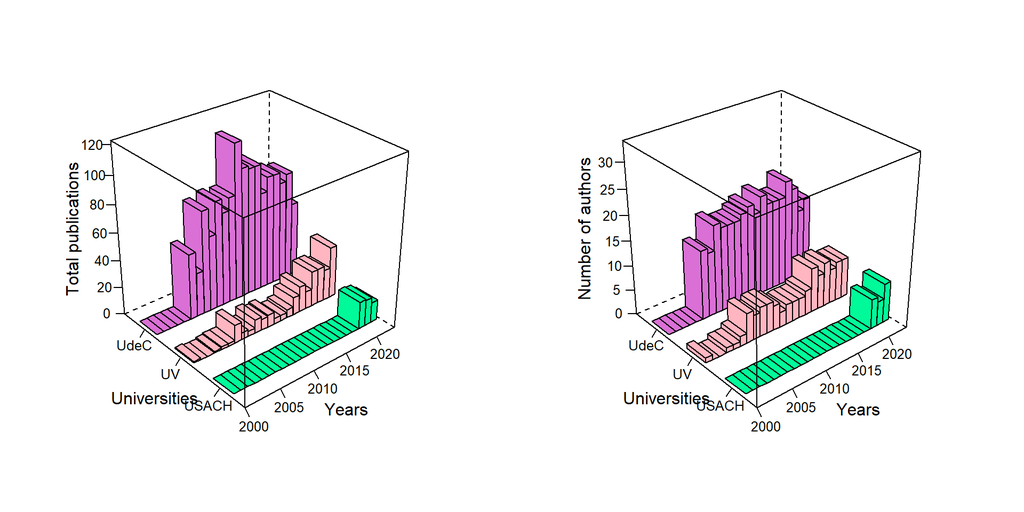

```r
# Load the ggplot2 library for creating visualizations
library("ggplot2")

# Load the latticeExtra library for extending lattice graphics
library("latticeExtra")

# Read data from the CSV file "BD_indexes.csv" with semicolon (;) as the delimiter and headers
datos = read.csv("Data/BD_indexes.csv", sep=";", header = TRUE)

# Convert the 'University' column to a factor and set custom order for levels
datos$University = factor(datos$University, levels=c('USACH', 'UV', 'UdeC'))

# Create a 3D cloud plot for TP (Total publications) using ggplot2 with specified parameters
g1 = cloud(TP ~ Year + University, datos, panel.3d.cloud=panel.3dbars, alpha.facet=1,
           col.facet=c("mediumspringgreen", "lightpink", "orchid")[datos$University],
           xbase=1, ybase=0.5, scales=list(arrows=FALSE, col=1), xlim=c(2000, 2023),
           par.settings=list(axis.line=list(col="transparent")), xlab="Years", ylab="Universities",
           zlab=list("Total publications", rot=90))

# Create a 3D cloud plot for NA_c (Number of authors) using ggplot2 with specified parameters
g2 = cloud(NA_c ~ Year + University, datos, panel.3d.cloud=panel.3dbars, alpha.facet=1,
           col.facet=c("mediumspringgreen", "lightpink", "orchid")[datos$University],
           xbase=1, ybase=0.5, scales=list(arrows=FALSE, col=1), xlim=c(2000, 2023),
           par.settings=list(axis.line=list(col="transparent")), xlab="Years", ylab="Universities",
           zlab=list("Number of authors", rot=90))

# Arrange the two 3D cloud plots in a grid layout with 2 columns
grid.arrange(g1, g2, ncol=2)
```

### 2.3 Area frequency

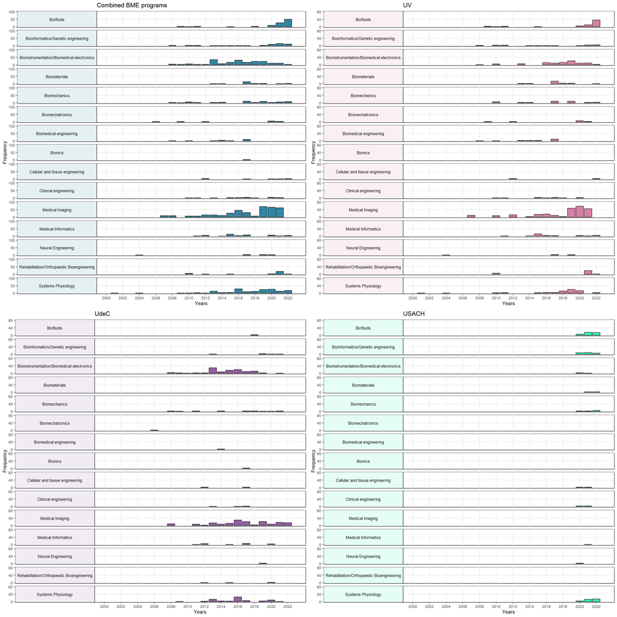

```r
# Load necessary libraries
library("ggplot2")  # For plotting
library("dplyr")  # For data manipulation


# Load the data from the specified CSV file
data_frequency = read.csv("Data/BD_graficos_keyword.csv", sep = ",", header = TRUE)


# Order the data by 'area'
data_frequency = data_frequency[order(data_frequency$area),]

# Convert 'area' to a factor with ordered levels
data_frequency$area = factor(data_frequency$area, levels = unique(sort(data_frequency$area,
                                                                       decreasing = FALSE)))

# Extract unique rows based on specified columns
data_filtered = unique(data_frequency[,-c(1, 2, 4, 6)])

# Convert 'Año' to numeric
data_filtered$Year = as.numeric(data_filtered$Año)

#=============================
# Frequency of publications for Biomedical Engineering
#=============================

# Create a plot for Biomedical Engineering
biomed_plot = ggplot() +
  geom_bar(data = data_filtered, aes(x = Año, y = frec_biomedica), stat = "identity",
           fill = "deepskyblue4", color = "black", alpha = 0.8) +
  facet_grid(area ~ ., switch = "y") +
  theme(
    strip.text.y.left = element_text(angle = 0),
    panel.grid.major = element_line(color = "gray90", size = 0.5),  # Color gris para las líneas de la grilla
    panel.grid.minor = element_blank(),  # Eliminar las líneas de grilla menores
    panel.background = element_rect(fill = "white", color = "black", size = 0.5, linetype = "solid"),  # Fondo blanco
    strip.background = element_rect(fill = alpha("deepskyblue4", 0.1), color = "black"),
      axis.text.x = element_text(size = 8),  # Set font size for the x-axis labels
      axis.text.y = element_text(size = 8),  # Set font size for the y-axis labels
      axis.title.x = element_text(size = 10),  # Set font size for the x-axis title
      axis.title.y = element_text(size = 10)   # Set font size for the y-axis title
  ) +
  ylab("Frequency") +
  xlab("Years") +
  scale_y_continuous(breaks = c(0, 50, 100), limits = c(0, 100))  + ggtitle("Combined BME programs") +
  scale_x_continuous(breaks = seq(2000, 2023, 2), limits = c(2000, 2023))  # Adjust x-axis breaks

#=============================
# UV (Universidad de Valparaíso)
#=============================

# Extract data for Universidad de Valparaíso (UV)
data_filtered = data_frequency[,-c(1,2,7)]
uv_data = data_filtered[data_filtered$Universidad == "UV",]
uv_data = unique(uv_data)

# Create a plot for UV
uv_plot = ggplot() +
  geom_bar(data = uv_data, aes(x = Año, y = frec_universidad), stat = "identity",
           fill = "hotpink3", color = "black", alpha = 0.8) +
  facet_grid(area ~ ., switch = "y") +
  theme(
    strip.text.y.left = element_text(angle = 0),
    panel.grid.major = element_line(color = "gray90", size = 0.5),  # Color gris para las líneas de la grilla
    panel.grid.minor = element_blank(),  # Eliminar las líneas de grilla menores
    panel.background = element_rect(fill = "white", color = "black", size = 0.5, linetype = "solid"),  # Fondo blanco
    strip.background = element_rect(fill = alpha("hotpink3", 0.1), color = "black"),
    axis.text.x = element_text(size = 8),  # Set font size for the x-axis labels
    axis.text.y = element_text(size = 8),  # Set font size for the y-axis labels
    axis.title.x = element_text(size = 10),  # Set font size for the x-axis title
    axis.title.y = element_text(size = 10)   # Set font size for the y-axis title
  ) +
  ylab("Frequency") +
  xlab("Years") +
  scale_y_continuous(breaks = c(0, 40, 80), limits = c(0, 80)) + ggtitle("UV") +
  scale_x_continuous(breaks = seq(2000, 2023, 2), limits = c(2000, 2023))  # Adjust x-axis breaks

#=============================
# UdeC (Universidad de Concepción)
#=============================

# Extract data for Universidad de Concepción (UdeC)
udec_data = data_filtered[data_filtered$Universidad == "UdeC",]
udec_data = unique(udec_data)

# Create a plot for UdeC
udec_plot = ggplot() +
  geom_bar(data = udec_data, aes(x = Año, y = frec_universidad), stat = "identity",
           fill = "mediumorchid4", color = "black", alpha = 0.8) +
  facet_grid(area ~ ., switch = "y") +
  theme(
    strip.text.y.left = element_text(angle = 0),
    panel.grid.major = element_line(color = "gray90", size = 0.5),  # Color gris para las líneas de la grilla
    panel.grid.minor = element_blank(),  # Eliminar las líneas de grilla menores
    panel.background = element_rect(fill = "white", color = "black", size = 0.5, linetype = "solid"),  # Fondo blanco
    strip.background = element_rect(fill = alpha("mediumorchid4", 0.1), color = "black"),
    axis.text.x = element_text(size = 8),  # Set font size for the x-axis labels
    axis.text.y = element_text(size = 8),  # Set font size for the y-axis labels
    axis.title.x = element_text(size = 10),  # Set font size for the x-axis title
    axis.title.y = element_text(size = 10)   # Set font size for the y-axis title
  ) +
  ylab("Frequency") +
  xlab("Years") +
  scale_y_continuous(breaks = c(0, 40, 80), limits = c(0, 80)) + ggtitle("UdeC") +
  scale_x_continuous(breaks = seq(2000, 2023, 2), limits = c(2000, 2023))  # Adjust x-axis breaks


#=============================
# USACH (Universidad de Santiago de Chile)
#=============================

# Extract data for Universidad de Santiago de Chile (USACH)
usach_data = data_filtered[data_filtered$Universidad == "USACH",]
usach_data = unique(usach_data)

# Create a plot for USACH
usach_plot = ggplot() +
  geom_bar(data = usach_data, aes(x = Año, y = frec_universidad), stat = "identity",
           fill = "mediumspringgreen", color = "black", alpha = 0.8) +
  facet_grid(area ~ ., switch = "y") +
  theme(
    strip.text.y.left = element_text(angle = 0),
    panel.grid.major = element_line(color = "gray90", size = 0.5),  # Color gris para las líneas de la grilla
    panel.grid.minor = element_blank(),  # Eliminar las líneas de grilla menores
    panel.background = element_rect(fill = "white", color = "black", size = 0.5, linetype = "solid"),  # Fondo blanco
    strip.background = element_rect(fill = alpha("mediumspringgreen", 0.1), color = "black"),
    axis.text.x = element_text(size = 8),  # Set font size for the x-axis labels
    axis.text.y = element_text(size = 8),  # Set font size for the y-axis labels
    axis.title.x = element_text(size = 10),  # Set font size for the x-axis title
    axis.title.y = element_text(size = 10)   # Set font size for the y-axis title
  ) +
  ylab("Frequency") +
  xlab("Years") +
  scale_y_continuous(breaks = c(0, 40, 80), limits = c(0, 80)) + ggtitle("USACH") +
  scale_x_continuous(breaks = seq(2000, 2023, 2), limits = c(2000, 2023))  # Adjust x-axis breaks


grid.arrange(biomed_plot, uv_plot, udec_plot, usach_plot, ncol=2,nrow=2)
```

### 2.4 Area relative frequency

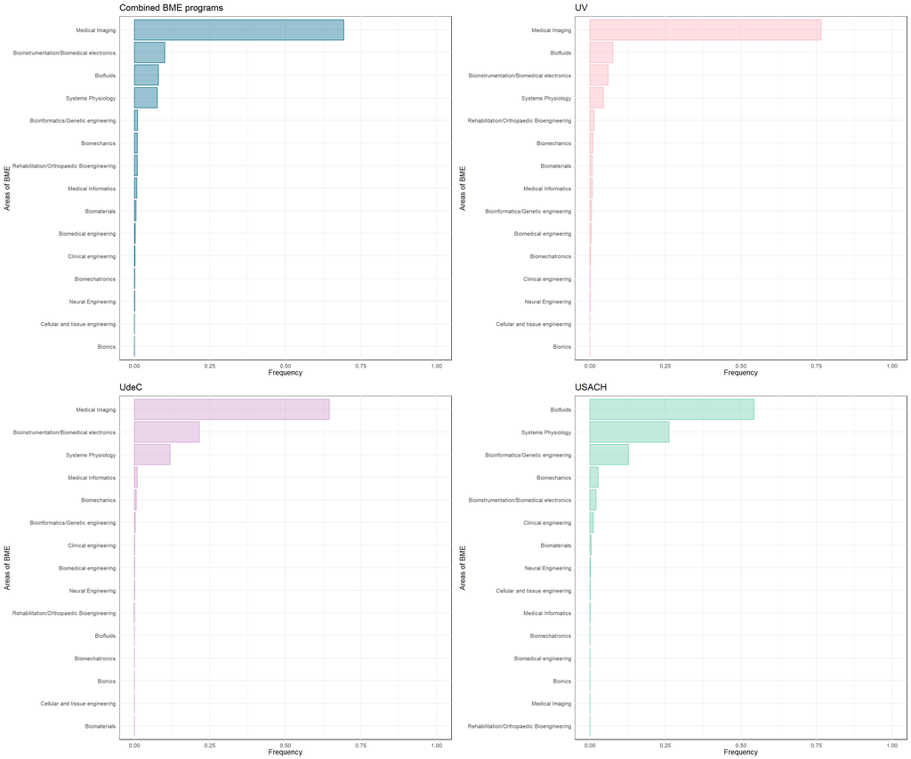

```r
# Read data from CSV file
data_plot = read.csv("Data/BD_graficos_keyword.csv", sep = ",", header = TRUE)

# Order data by 'area'
data_tmp = data_plot[order(data_plot$area),]

# Exclude rows where keyword is "NONE" and calculate the total frequency for each area
data_exclude = data_tmp[data_tmp$keyword == "NONE",]
data_exclude = data_exclude %>%
  group_by(area) %>% summarise(Frequency = sum(frec_biomedica))

# Calculate total frequency for each area
data_tmp = data_tmp %>%
  group_by(area) %>% summarise(Frequency = sum(frec_biomedica))

# Subtract excluded frequencies from total frequencies
data_tmp$Frequency = data_tmp$Frequency - data_exclude$Frequency

# Normalize frequencies to get proportions
data_tmp$Frequency = data_tmp$Frequency / sum(data_tmp$Frequency)

# Convert area to factor and order levels in descending order
data_tmp = data.frame(data_tmp)
data_tmp$area = factor(data_tmp$area, levels = unique(sort(data_tmp$area, decreasing = TRUE)))

# Create bar plot
bar_plot = ggplot(data_tmp, aes(x = reorder(area, Frequency), y = Frequency)) +
  geom_bar(stat = "identity", fill = "deepskyblue4", alpha = 0.4, color = "deepskyblue4") +
  theme_minimal() +
  coord_flip() +
  labs(x = "Areas of BME") +
  theme(axis.text.y = element_text(size = 8),
        axis.title.x = element_blank(),
        panel.background = element_rect(fill = "white", color = "black", size = 0.5, linetype = "solid"),
        legend.position = "none") +
  ylim(0, 1) + ggtitle("Combined BME programs") +
  theme(
      axis.text.x = element_text(size = 8),  # Set font size for the x-axis labels
      axis.text.y = element_text(size = 8),  # Set font size for the y-axis labels
      axis.title.x = element_text(size = 10),  # Set font size for the x-axis title
      axis.title.y = element_text(size = 10)   # Set font size for the y-axis title
  )



# Universities and corresponding colors
universities = c("UV", "UdeC", "USACH")
colors = c("lightpink1", "plum3", "mediumaquamarine")
counter = 0
plots_list = list()
plots_list[[1]] = bar_plot

# Loop through universities
for (a in universities) {
  counter = counter + 1
  data_tmp = data_plot[order(data_plot$area),]

  # Filter data for the current university
  data_tmp = data_tmp[data_tmp$Universidad == a,]

  # Exclude rows where keyword is "NONE" and calculate total frequency for each area
  data_exclude = data_tmp[data_tmp$keyword == "NONE",]
  data_exclude = data_exclude %>%
    group_by(area) %>% summarise(Frequency = sum(frec_biomedica))

  # Calculate total frequency for each area and subtract excluded frequencies
  data_tmp = data_tmp %>%
    group_by(area) %>% summarise(Frequency = sum(frec_biomedica))
  data_tmp$Frequency = data_tmp$Frequency - data_exclude$Frequency
  data_tmp$Frequency=data_tmp$Frequency/sum(data_tmp$Frequency)

  data_tmp = data.frame(data_tmp)
  data_tmp$area = factor(data_tmp$area, levels=unique(sort(data_tmp$area,decreasing = T)))

  # Create bar plot for the current university
  plots_list[[counter+1]] = ggplot(data_tmp, aes(x = reorder(area, Frequency), y = Frequency)) +
    geom_bar(stat = "identity", fill = colors[counter], alpha = 0.4, color = colors[counter]) +
    theme_minimal() +
    coord_flip() +
    labs(x = "Areas of BME") +
    theme(axis.text.y = element_text(size = 8),
          panel.background = element_rect(fill = "white", color = "black", size = 0.5, linetype = "solid"),
          axis.title.x = element_blank(),
          legend.position = "none") + ggtitle(universities[counter]) +
    ylim(0, 1) +
    theme(
      axis.text.x = element_text(size = 8),  # Set font size for the x-axis labels
      axis.text.y = element_text(size = 8),  # Set font size for the y-axis labels
      axis.title.x = element_text(size = 10),  # Set font size for the x-axis title
      axis.title.y = element_text(size = 10)   # Set font size for the y-axis title
    )

}

grid.arrange(grobs = plots_list, ncol = 2)
```

### 2.5 Keyword frequency

```r
# Extract unique rows based on specified columns
data_filtered = unique(data_frequency[,-c(1, 4, 6)])

# Convert 'Año' to numeric
data_filtered$Año = as.numeric(data_filtered$Año)


# Define a function to generate the plot for each area
plot_frequency = function(data, plot_title) {
  # Generate the density plot
  g = ggplot() +
    geom_bar(data = data, aes(x = Año, y = frec_biomedica), stat = "identity",
             fill = "deepskyblue4", color = "black", alpha = 0.8) +
    facet_grid(keyword ~ ., switch = "y") +
    theme(
      strip.text.y.left = element_text(angle = 0),
    panel.grid.major = element_line(color = "gray90", size = 0.5),  # Color gris para las líneas de la grilla
    panel.grid.minor = element_blank(),  # Eliminar las líneas de grilla menores
    panel.background = element_rect(fill = "white", color = "black", size = 0.5, linetype = "solid"),  # Fondo blanco
    strip.background = element_rect(fill = alpha("deepskyblue4", 0.1), colour = "black"),
      axis.text.x = element_text(size = 8),  # Set font size for the x-axis labels
      axis.text.y = element_text(size = 8),  # Set font size for the y-axis labels
      axis.title.x = element_text(size = 10),  # Set font size for the x-axis title
      axis.title.y = element_text(size = 10)   # Set font size for the y-axis title
    ) +
    ylab("Frequency") + ggtitle(plot_title) +
    xlab("Years") +
    scale_y_continuous(breaks = c(0, 50, 110), limits = c(0, 110)) +
    scale_x_continuous(breaks = seq(2000, 2023, 2), limits = c(2000, 2023))  # Adjust x-axis breaks

  return(g)
}

# Get unique areas from the data
areas = unique(data_filtered$area)
plots_list = list()

# Generate and plot frequency plots for each area
for (a in areas) {
  data_area = data_filtered[which(data_filtered$area == a & data_filtered$keyword != "NONE"),]
  plot_title = paste("Frequency of Publications for", a)  # Set plot title
  g = plot_frequency(data_area, plot_title)  # Generate the plot
  plots_list[[a]] = g
}

grid.arrange(grobs = plots_list, ncol = 2)
```

[figure not shown]

### 2.6 Clustering

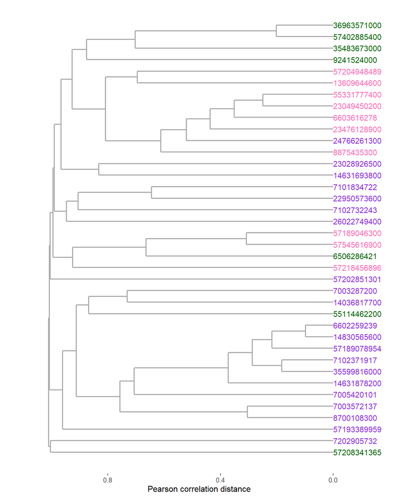

```r
# Load required libraries
library("ggdendro")
library("ggplot2")
library("plotly")
library("dplyr")
library("shiny")
library("shinythemes")
library("DT")
library("stringr")
library("wordcloud2")
library("quanteda")
library("quanteda.textplots")
library("quanteda.corpora")
library("quanteda.textmodels")
library("quanteda.textstats")
library("quanteda.textplots")
library("RColorBrewer")
library("treemapify")
library("ggwordcloud")
library("NbClust")
library("networkD3")
library("tidyr")
library("stringi")

# Read data from CSV files
data_db = read.csv("Data/BD_Biomedica - BD.csv", sep = ";", header = TRUE)
data_main = read.csv("Data/BD_Biomedica - Main.csv", sep = ";", header = TRUE)
data_thesaurus = read.csv("Data/BD_IEEE_tesauro.csv", sep = ";", header = TRUE)
data_keywords = read.csv("Data/BD_SCOPUS_keywords.csv", sep = ";", header = TRUE)

# Filter data for the specified period
ini_year = 2020
last_year = 2022
data_db_tmp = data_db %>% filter(Año %in% (ini_year:last_year))

# Create thesaurus list
thesaurus = unique(data_keywords$Keywords)

# Preprocess the text data
corpus_text = corpus(data_db_tmp, text_field = "Index.keywords")
token_text = tokens(corpus_text, remove_punct = TRUE, remove_symbols = TRUE, remove_numbers = TRUE,
                    remove_url = TRUE, remove_separators = TRUE)
token_text = tokens_tolower(token_text)

# Find keywords in the text data using the thesaurus list
kwick_text = kwic(token_text, pattern = phrase(thesaurus))
kwick_text$from = kwick_text$from = kwick_text$to = kwick_text$pre = kwick_text$post = kwick_text$pattern = NULL

# Merge text data with metadata
corpus_text = summary(corpus_text, n = length(kwick_text$docname))
kwick_text = merge(kwick_text, corpus_text[, c("Text", "Año")], by.x = "docname", by.y = "Text")
kwick_text = merge(kwick_text, corpus_text[, c("Text", "Universidad")], by.x = "docname", by.y = "Text")
kwick_text = merge(kwick_text, corpus_text[, c("Text", "Nombre")], by.x = "docname", by.y = "Text")

# Preprocess the text data for clustering
corpus_text = corpus(kwick_text, text_field = "keyword")
token_text = tokens(corpus_text)
token_text = tokens_compound(token_text, pattern = phrase(thesaurus))

# Create a document-feature matrix
df_text = dfm(token_text)

# Group the features by user
dfmat_users = dfm_group(df_text, groups = Nombre)

# Calculate pairwise correlation distance between users based on text data
tstat_dist = 1 - as.dist(textstat_simil(dfmat_users, method = "correlation"))

# Perform hierarchical clustering on the correlation distance matrix
user_clust = hclust(tstat_dist, method = "average")
idx = match(user_clust$labels, data_main$Nombre)
codes = data_main$Codigo.Scopus[idx]
user_clust$labels = codes

# Convert the hierarchical clustering result to dendrogram format
dendr = as.dendrogram(user_clust)

# Extract dendrogram data for plotting
dendr = dendro_data(dendr, type = "rectangle")
colores = merge(dendr$labels, data_main, by.x = "label", by.y = "Codigo.Scopus", sort = FALSE)[[6]]

# Map university colors
colores[which(colores == "plum3")] = "blueviolet"
colores[which(colores == "mediumspringgreen")] = "hotpink"
colores[which(colores == "lightpink")] = "darkgreen"

# Add university colors to the dendrogram labels
dendr$labels$colores = colores

# Create and customize the dendrogram plot
g = ggplot() +
  geom_segment(data = segment(dendr), aes(x = x, y = y, xend = xend, yend = yend), color = "darkgray", size = 0.8) +
  geom_text(data = label(dendr), aes(x = x, y = y, label = label, hjust = 0, color = colores), size = 4) +
  coord_flip() + scale_y_reverse(expand = c(0.3, 0)) +
  theme(axis.line.y = element_blank(),
        axis.ticks.y = element_blank(), text = element_text(size = 12),
        axis.text.y = element_blank(),
        axis.title.y = element_blank(),
        panel.background = element_rect(fill = "white"), legend.position = "NULL",
        panel.grid = element_blank()) + ylab("Pearson correlation distance") + ylim(1.1, -0.15) +
  scale_colour_manual(values = c("blueviolet", "hotpink", "darkgreen"),
                      labels = c("UdeC", "UV", "USACH")) +
  guides(color = guide_legend(title = "Universities"))

# Print the dendrogram plot
plot(g)
```

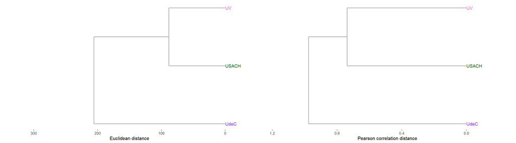

```r
# By university

 corpus_text = corpus(data_db_tmp, text_field = "Index.keywords")
 token_text = tokens(corpus_text,remove_punct = T,remove_symbols = T, remove_numbers = T, remove_url = T,remove_separators = T)
 token_text = tokens_tolower(token_text)
 kwick_text = kwic(token_text, pattern = phrase(thesaurus))
 kwick_text$from=kwick_text$from=kwick_text$to=kwick_text$pre=kwick_text$post=kwick_text$pattern=NULL
 corpus_text =summary(corpus_text,n=length(kwick_text$docname))
 kwick_text=merge(kwick_text,corpus_text[,c("Text","Año")],by.x="docname",by.y = "Text")
 kwick_text=merge(kwick_text,corpus_text[,c("Text","Universidad")],by.x="docname",by.y = "Text")
 kwick_text=merge(kwick_text,corpus_text[,c("Text","Nombre")],by.x="docname",by.y = "Text")
 corpus_text = corpus(kwick_text,text_field="keyword")
 token_text = tokens(corpus_text)
 token_text = tokens_compound(token_text, pattern = phrase(thesaurus))

 df_text = dfm(token_text)
 dfmat_users = dfm_group(df_text, groups = Universidad)

 tstat_dist = as.dist(textstat_dist(dfmat_users,method="euclidean"))

 user_clust = hclust(tstat_dist,method = "average")

 colores=c("blueviolet","darkgreen","hotpink")
 colores = colores[1:length(unique(user_clust$labels))]

 dendr2 = dendro_data(user_clust, type="rectangle")

 g1 = ggplot() +
   geom_segment(data=segment(dendr2), aes(x=x, y=y, xend=xend, yend=yend),color = "darkgray",size=0.8) +
   geom_text(data=label(dendr2), aes(x=x, y=y, label=label, hjust=0), size=4, color = colores) +
   coord_flip() + scale_y_reverse(expand=c(0.3, 0)) +
   theme(axis.line.y=element_blank(),
         axis.ticks.y=element_blank(),
         axis.text.y=element_blank(), text = element_text(size = 12),
         axis.title.y=element_blank(),
         panel.background=element_rect(fill="white"),
         panel.grid=element_blank()) + ylab("Euclidean distance") + ylim(330,-30)



 tstat_dist = 1 - as.dist(textstat_simil(dfmat_users,method="correlation"))
 user_clust = hclust(tstat_dist,method = "average")

 colores=c("blueviolet","darkgreen","hotpink")
 colores = colores[1:length(unique(user_clust$labels))]

 dendr2 = dendro_data(user_clust, type="rectangle")

g2 = ggplot() +
   geom_segment(data=segment(dendr2), aes(x=x, y=y, xend=xend, yend=yend),color = "darkgray",size=0.8) +
   geom_text(data=label(dendr2), aes(x=x, y=y, label=label, hjust=0), size=4, color = colores) +
   coord_flip() + scale_y_reverse(expand=c(0.3, 0)) +
   theme(axis.line.y=element_blank(),
         axis.ticks.y=element_blank(),
         axis.text.y=element_blank(), text = element_text(size = 12),
         axis.title.y=element_blank(),
         panel.background=element_rect(fill="white"),
         panel.grid=element_blank()) + ylab("Pearson correlation distance")

grid.arrange(g1,g2, ncol = 2)
```

### 2.7 Collaborations

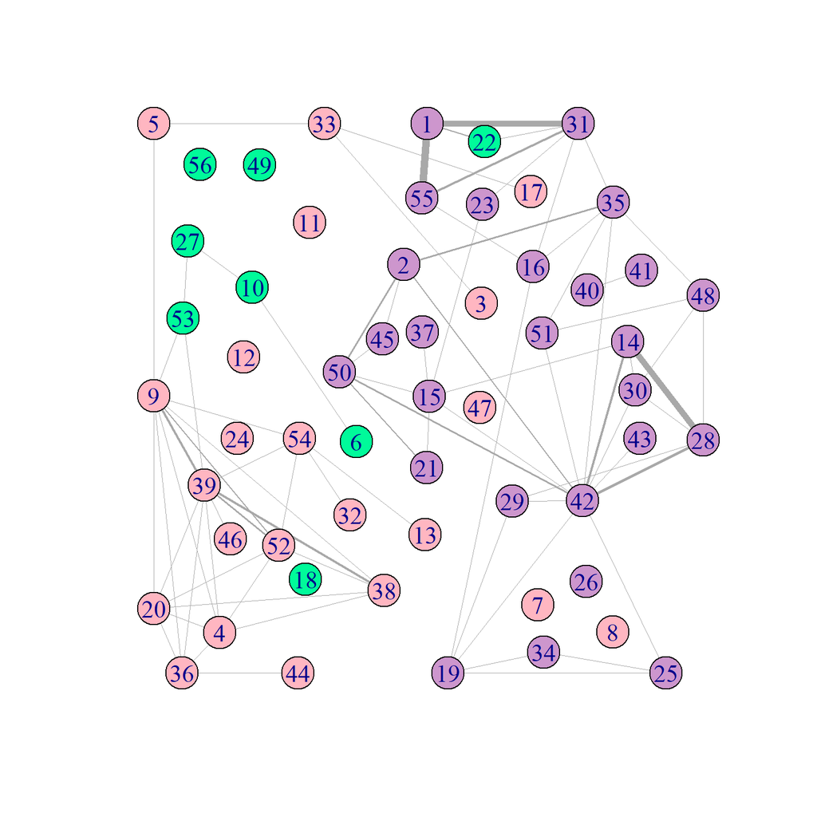

```r
library("igraph")

data_main=data_main[order(data_main$Nombre),]

autores_base = data_main$Codigo.Scopus

matriz = matrix(0,length(autores_base),length(autores_base))

colnames(matriz)=rownames(matriz)=data_main$Nombre

for (a in 1:length(data_db$Author.s..ID))
{
  autores = strsplit(data_db$Author.s..ID[a],"-")[[1]]
  interseccion = which(is.element(autores_base,autores))
  #print(paste(a,"-",interseccion))

  if (length(interseccion)>1)
  {combinaciones = combn(interseccion,2,simplify = F)


    for (b in 1:length(combinaciones))
    {
      pos_x = combinaciones[[b]][1]
      pos_y = combinaciones[[b]][2]

      #print(paste(a,"---",data_main$Nombre[pos_x],"-",data_main$Nombre[pos_y]))

      matriz[pos_x,pos_y]=matriz[pos_x,pos_y]+1
      matriz[pos_y,pos_x]=matriz[pos_y,pos_x]+1
    }
  # print(a)
  }


}

# Ajuste Felipe Bello
matriz[6,]=matriz[7,]+matriz[8,]
matriz[,6]=matriz[,7]+matriz[,8]
matriz = matriz[c(-7,-8),c(-7,-8)]

diag(matriz) = 0

g = graph.adjacency(matriz, mode="undirected", weighted=TRUE)
set.seed(20)
nombres = V(g)$name
colores = data_main$Colores
colores=colores[-c(7,8)]

l=layout_(g, with_dh(weight.edge.lengths = edge_density(g)/1000))
V(g)$label.cex = 1.4
V(g)$name = seq(1:ncol(matriz))
plot(g, layout=l, vertex.color=colores, edge.color="darkgray", edge.width=E(g)$weight/15,
     vertex.size = 12)
```

Analyzing collaboration patterns over time using a regression model.

```r
years = sort(unique(data_db$Año))
years = years[-which(years>2022)]

counter_year = years*0
idx = 0

for (a in years)
{
  idx = idx + 1


  filter_papers = data_db[which(data_db$Año==a),]

  counter = NULL

  for (b in 1:length(filter_papers$Author.s..ID))
  {
     counter[b] = sum(autores_base %in% strsplit(filter_papers$Author.s..ID[b],"-")[[1]])

  }

  counter_year[idx] = length(which(counter>1))
}

data_lm = data.frame(years,counter_year)

regresion = lm(counter_year~years,data = data_lm)

summary(regresion)
```

```
##
## Call:
## lm(formula = counter_year ~ years, data = data_lm)
##
## Residuals:
##      Min       1Q   Median       3Q      Max
## -17.5420  -7.9308   0.0598   3.7126  24.8994
##
## Coefficients:
##               Estimate Std. Error t value Pr(>|t|)
## (Intercept) -4062.0828   947.2709  -4.288 0.000443 ***
## years           2.0340     0.4707   4.321 0.000411 ***
## ---
## Signif. codes:  0 '***' 0.001 '**' 0.01 '*' 0.05 '.' 0.1 ' ' 1
##
## Residual standard error: 12.51 on 18 degrees of freedom
## Multiple R-squared:  0.5091, Adjusted R-squared:  0.4819
## F-statistic: 18.67 on 1 and 18 DF,  p-value: 0.0004115
```

```r
cor.test(years,counter_year)
```

```
##
##  Pearson's product-moment correlation
##
## data:  years and counter_year
## t = 4.321, df = 18, p-value = 0.0004115
## alternative hypothesis: true correlation is not equal to 0
## 95 percent confidence interval:
##  0.3960969 0.8786314
## sample estimates:
##       cor
## 0.7135465
```